# Covariate Adjustments and Baseline Correction in Clinical Trials

# Introduction

Welcome to this scintillating ride through clinical trial simulations! We’ll see how a well-chosen covariate can perform miracles, and how baseline correction can polish up your results. I’ll aim to demonstrate **why** would all those things you were thought were good actually are good.

**What we’ll be doing:**

- **Basic two-arm study** with a straightforward treatment effect.
- **Hiding behind a covariate**: a monstrous driver of outcomes that, if ignored, will make you cry.
- **Baseline correction**: The why we’re not just analyzing change.
- **Spline on baseline** just to be fancy about it.

We’ll do this via simulation;generating data based on a set of rules, because this way we are only limited by RAM and CPU time.

```r
    # Keeping global chunk options
    knitr::opts_chunk$set(echo = TRUE)
```

# 1. The Simplest Study

When you’re brand new to the idea of analyzing two groups, the simplest scenario is one treatment effect, two arms, and normal data. No surprises, no drama.

## Simulation Function

```r
    library(emmeans)
    library(dplyr)
    library(ggplot2)
    library(mvtnorm)
    library(splines)
    library(effects)

    set.seed(1234)

    # Minimal function: 2 arms, effect 'eff', and noise ~N(0, sd).
    sim_simplest_study <- function(n_g = 5, eff = 10, sd = 3) {
      dat <- data.frame(
        arm = rep(1:2, each = n_g)
      )
      dat$y <- 0 + eff * dat$arm + rnorm(nrow(dat), 0, sd)
      return(dat)
    }

    dat <- sim_simplest_study()
    head(dat, 10)
```

|  | arm | y |
| --- | --- | --- |
| 1 | 1 | 6.378803 |
| 2 | 1 | 10.832288 |
| 3 | 1 | 13.253324 |
| 4 | 1 | 2.962907 |
| 5 | 1 | 11.287374 |
| 6 | 2 | 21.518168 |
| 7 | 2 | 18.275780 |
| 8 | 2 | 18.360104 |
| 9 | 2 | 18.306644 |
| 10 | 2 | 17.329887 |

Check the difference with a plain old t-test. Due to the magintude of the effect compared to the variability, its significant:

```r
    t.test(y ~ arm, data = dat)
```

```
##
##  Welch Two Sample t-test
##
## data:  y by arm
## t = -4.9004, df = 5.1474, p-value = 0.004134
## alternative hypothesis: true difference in means between group 1 and group 2 is not equal to 0
## 95 percent confidence interval:
##  -14.919807  -4.710549
## sample estimates:
## mean in group 1 mean in group 2
##        8.942939       18.758117
```

## Linear Model + emmeans

The `emmeans` package helps us estimate marginal means and contrasts (differences). It also has a more robust approach for degrees of freedom, especially when you have more complex models (this is why its different from the Welch test).

```r
    mod <- lm(y ~ arm, data = dat)
    emmeans(mod, "arm") %>%
      contrast("pairwise")
```

```
##  contrast    estimate SE df t.ratio p.value
##  arm1 - arm2    -9.82  2  8  -4.900  0.0012
```

## Repeated Simulations

Of course, one dataset isn’t conclusive when thinking about methodology. Let’s replicate the scenario 200 times and see how often our 95% confidence intervals bracket the true effect.

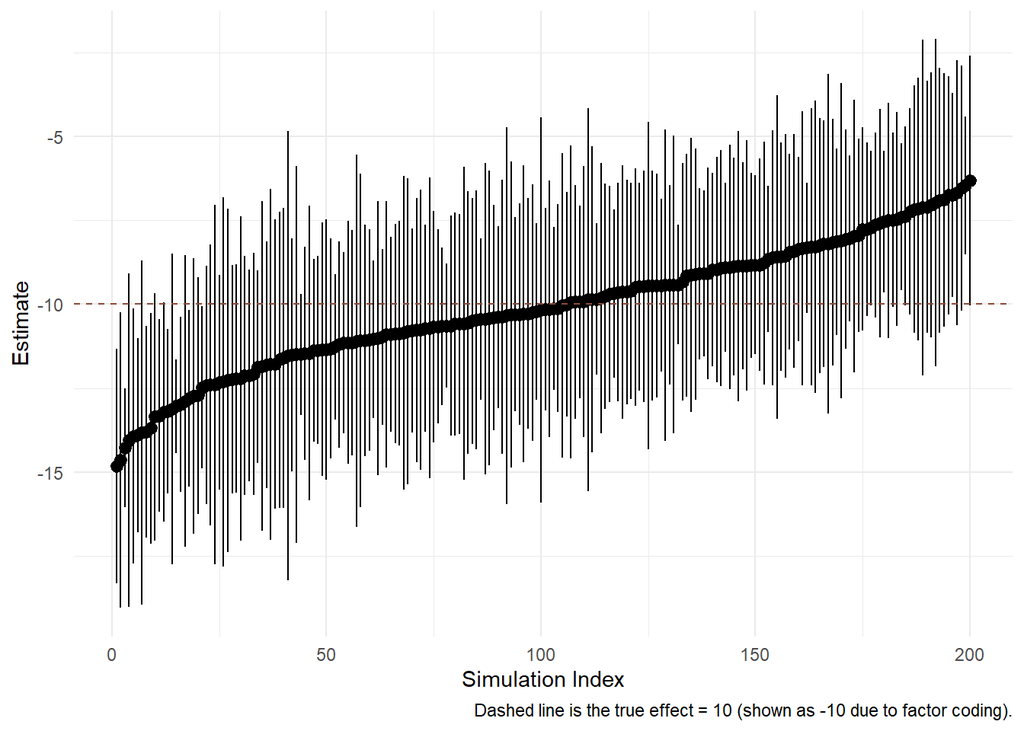

```r
    n_sim <- 200
    p_simplest <- data.frame(
      contrast= rep(NA, n_sim),
      estimate= rep(NA, n_sim),
      SE      = rep(NA, n_sim),
      df      = rep(NA, n_sim),
      t.ratio = rep(NA, n_sim),
      p.value = rep(NA, n_sim)
    )

    # Commenting out the progress bar to keep things simpler:
    # pb <- txtProgressBar(min = 0, max = n_sim, style = 3)

    for (i in 1:n_sim) {
      dat <- sim_simplest_study()
      mod <- lm(y ~ arm, data = dat)
      p_simplest[i, ] <- emmeans(mod, "arm") %>%
        contrast("pairwise") %>%
        as.data.frame()
      # setTxtProgressBar(pb, i)
    }
    # close(pb)

    p_simplest <- p_simplest %>%
      mutate(
        ci_low = estimate - 1.96 * SE,
        ci_upp = estimate + 1.96 * SE
      ) %>%
      arrange(estimate) %>%
      mutate(id = row_number())

      p_simplest %>%
      ggplot(aes(ymin = ci_low, ymax = ci_upp, x = id, y = estimate)) +
      geom_pointrange() +
      geom_hline(yintercept = -10, linetype = "dashed", color = "salmon4") +
      theme_minimal() +
      labs(x = "Simulation Index", y = "Estimate",
           caption = "Dashed line is the true effect = 10 (shown as -10 due to factor coding).")
```

*(Yes, the sign might be flipped because of how the factor is coded. Don’t fret; it’s still ±10 in magnitude.)*

# 2. Covariate Adjustments

Now let’s get theatrical. Imagine a **huge** driver of the outcome—say a baseline patient trait that 10x-s your little treatment effect. Randomization is your friend, but if you don’t explicitly account for that trait in the analysis, you might need a huge sample size because you would be observing a huge variation in the outcome.

## Simulation Function

```r
    sim_cov_study <- function(n_g = 5, eff = 10, eff_cov = 100, sd = 3) {
      dat <- data.frame(
        arm = rep(1:2, each = n_g),
        cov = rep(1:2, n_g)
      )
      # Shuffle the covariate assignment
      dat$cov <- sample(dat$cov)
      # The outcome is heavily driven by 'cov'
      dat$y <- 0 + eff * dat$arm + eff_cov * dat$cov + rnorm(nrow(dat), 0, sd)
      return(dat)
    }

    dat <- sim_cov_study()
```

### Ignoring the Covariate

```r
    t.test(y ~ arm, data = dat)
```

```
##
##  Welch Two Sample t-test
##
## data:  y by arm
## t = 0.29696, df = 7.9985, p-value = 0.7741
## alternative hypothesis: true difference in means between group 1 and group 2 is not equal to 0
## 95 percent confidence interval:
##  -68.57353  88.84470
## sample estimates:
## mean in group 1 mean in group 2
##        171.4535        161.3179
```

No significance, because that gargantuan covariate effect which adds to the observed variability of the outcom is overshadowing the treatment difference. The linear model ignoring the covariate confirms this:

```r
    mod <- lm(y ~ arm, data = dat)
    emmeans(mod, "arm") %>%
      contrast("pairwise")
```

```
##  contrast    estimate   SE df t.ratio p.value
##  arm1 - arm2     10.1 34.1  8   0.297  0.7741
```

### Including the Covariate

```r
    mod_cov <- lm(y ~ arm + cov, data = dat)
    emmeans(mod_cov, "arm") %>%
      contrast("pairwise")
```

```
##  contrast    estimate   SE df t.ratio p.value
##  arm1 - arm2    -9.54 2.19  7  -4.356  0.0033
##
## Results are averaged over the levels of: cov
```

Magically, your effect is back in the limelight. By adjusting for the covariate, you reduce the unexplained variation in your model and more precisely isolate the treatment effect. Applause.

### Simulation

Below is a very nice illustration of the phenomenon.

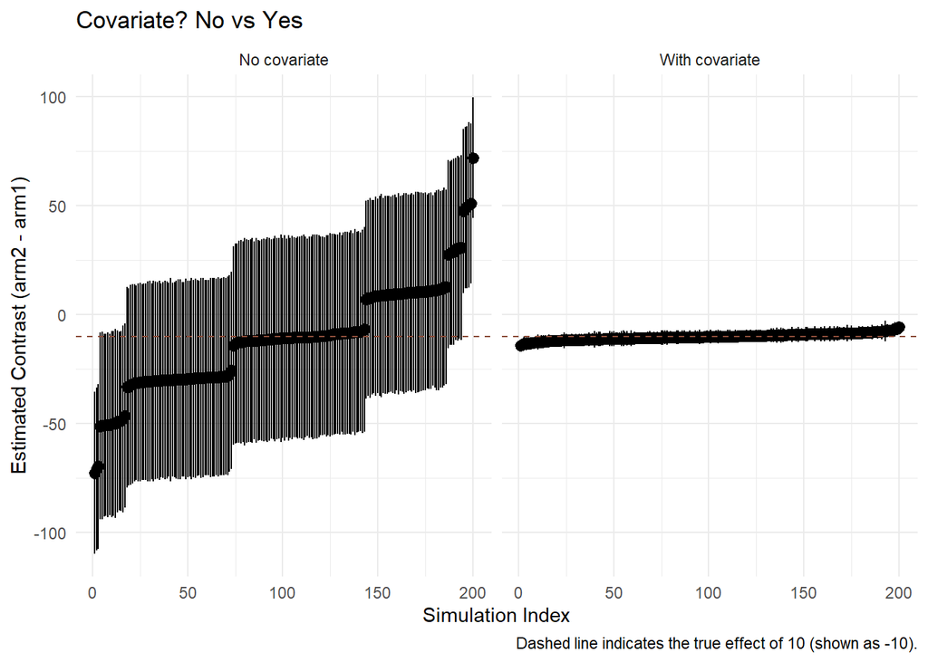

```r
    set.seed(999)
    n_sim <- 200
    p_cov_combined <- data.frame()

    # pb <- txtProgressBar(min = 0, max = n_sim, style = 3)

    for (i in 1:n_sim) {
      dat <- sim_cov_study(n_g = 10, eff = 10)

      # Model w/o the covariate
      mod_nocov <- lm(y ~ arm, data = dat)
      res_nocov <- emmeans(mod_nocov, "arm") %>%
        contrast("pairwise") %>%
        as.data.frame()
      res_nocov$model <- "No covariate"
      res_nocov$rep <- i

      # Model w/ the covariate
      mod_withcov <- lm(y ~ arm + cov, data = dat)
      res_withcov <- emmeans(mod_withcov, "arm") %>%
        contrast("pairwise") %>%
        as.data.frame()
      res_withcov$model <- "With covariate"
      res_withcov$rep <- i

      p_cov_combined <- rbind(p_cov_combined, res_nocov, res_withcov)
      # setTxtProgressBar(pb, i)
    }
    # close(pb)

    p_cov_combined <- p_cov_combined %>%
      mutate(
        ci_low = estimate - 1.96 * SE,
        ci_upp = estimate + 1.96 * SE
      )

    p_cov_combined <- p_cov_combined %>%
      group_by(model) %>%
      arrange(estimate, .by_group = TRUE) %>%
      mutate(id = row_number()) %>%
      ungroup()

      ggplot(p_cov_combined, aes(x = id, y = estimate, ymin = ci_low, ymax = ci_upp)) +
      geom_pointrange() +
      facet_wrap(~ model, scales = "free_x") +
      geom_hline(yintercept = -10, linetype = "dashed", color = "salmon4") +
      theme_minimal() +
      labs(
        x = "Simulation Index",
        y = "Estimated Contrast (arm2 - arm1)",
        title = "Covariate? No vs Yes",
        caption = "Dashed line indicates the true effect of 10 (shown as -10)."
      )
```

Notice how “No covariate” bounces around widely (with “clusters” denoting the per arm distribution of the covariate), whereas “With covariate” aligns with the known effect with a confidence resembling that of the scenario described before.

# 3. Baseline Correction

Rather than a single measurement post-randomization, most clinical trials measure an outcome both at baseline and after treatment. We’re often interested in the *change* from baseline; did the change differ for different treatments?

The baseline is usually somewhat correlated with the follow-up. Including both the baseline and the follow-up value adds information to the model, and since the outcome is correlated with the baseline, a certain amount of variability can be explained by taking it into consideration.

Inputting both baseline and follow-up is actually better than just looking at the change, especially if the follow-up is only loosely correlated with the baseline.

## Simulation

We use a bivariate normal setup for (baseline, follow-up), with some correlation `eff_corr`. For arm 2, the follow-up has an extra `eff` shift. Values are derived from a multivariate normal distribution with a known covriance matrix using the *mvtnorm* package.

```r
    sim_baseline_study <- function(
        n_g      = 5,       # subjects per arm
        eff      = 10,      # difference in follow-up for arm2
        eff_corr = 0.5,     # correlation between baseline & follow-up
        sd       = 3
    ) {
      # Covariance matrix with correlation
      Sigma <- matrix(
        c(sd^2, eff_corr * sd^2,
          eff_corr * sd^2, sd^2),
        nrow = 2
      )

      all_data <- list()

      for (arm_id in 1:2) {
        # mean is (0,0) if arm1, or (0, eff) if arm2
        mean_vec <- if(arm_id == 1) c(0, 0) else c(0, eff)

        Y <- rmvnorm(n_g, mean = mean_vec, sigma = Sigma)
        subject_id <- paste0(arm_id, "_", seq_len(n_g))

        df_arm <- data.frame(
          id       = subject_id,
          arm      = factor(arm_id, levels = c(1,2), labels = c("arm1","arm2")),
          y_before = Y[,1],
          y_after  = Y[,2]
        )
        all_data[[arm_id]] <- df_arm
      }

      # Combine, add a change column
      dat_wide <- do.call(rbind, all_data) %>%
        mutate(change = y_after - y_before)

      return(dat_wide)
    }

    set.seed(42)
    dat <- sim_baseline_study(n_g = 10, eff = 10, eff_corr = 0.6, sd = 3)
    head(dat[sample(1:nrow(dat)), ], 10)
```

|  | id | arm | y_before | y_after | change |
| --- | --- | --- | --- | --- | --- |
| 4 | 1_4 | arm1 | 4.2120656 | 1.16455133 | -3.0475142 |
| 13 | 2_3 | arm2 | 4.9854363 | 10.57280176 | 5.5873655 |
| 10 | 1_10 | arm1 | -5.6933212 | 1.44187823 | 7.1351994 |
| 9 | 1_9 | arm1 | -3.3291329 | -7.83007067 | -4.5009378 |
| 19 | 2_9 | arm2 | -3.0398513 | 6.83407137 | 9.8739227 |
| 12 | 2_2 | arm2 | 0.6630562 | 13.29392967 | 12.6308734 |
| 20 | 2_10 | arm2 | -6.8366865 | 7.81248827 | 14.6491748 |
| 17 | 2_7 | arm2 | 2.3682780 | 9.24895058 | 6.8806726 |
| 11 | 2_1 | arm2 | -2.5626063 | 4.63940441 | 7.2020107 |
| 3 | 1_3 | arm1 | 1.0498893 | 0.08148694 | -0.9684023 |

### Comparing Models

1. **Naive**: just look at `change ~ arm`.
2. **Baseline correction**: look at `y_after ~ arm + y_before`, which can reduce variance when `y_before` is highly predictive.

The second setup results in smaller standard errors.

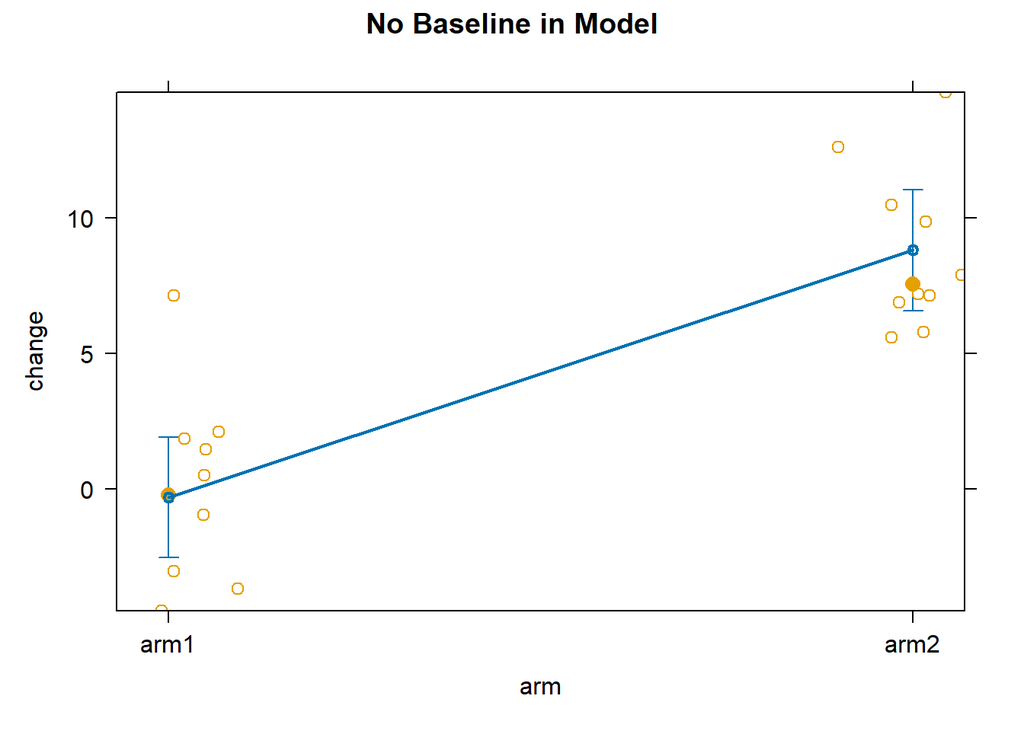

```r
    mod_simp <- lm(change ~ arm, data = dat)
    mod_simp %>% effects::predictorEffects(partial.residuals = TRUE) %>% plot(main="No Baseline in Model")
```

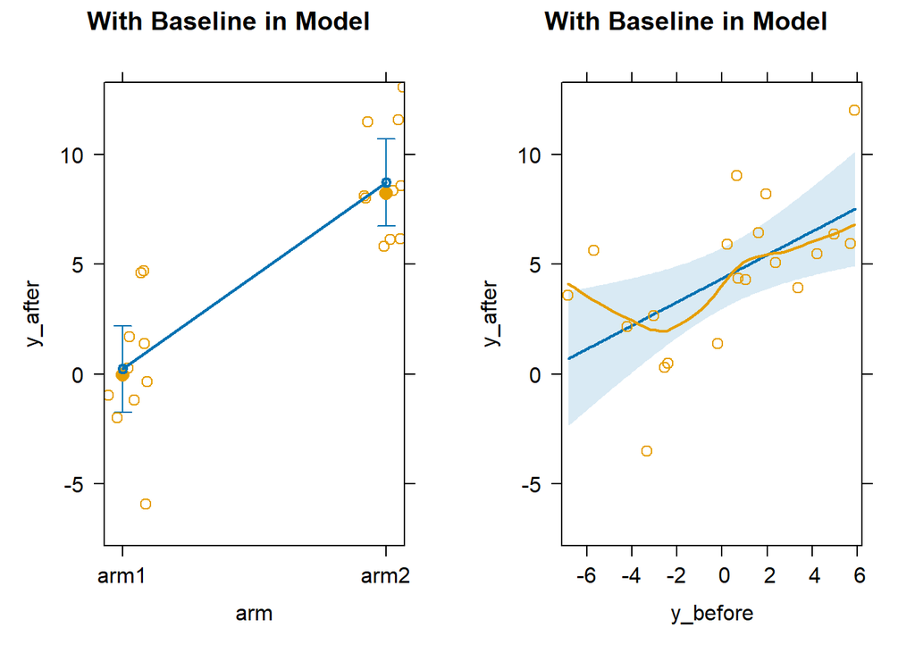

```r
    mod <- lm(y_after ~ arm + y_before, data = dat)
    mod %>% effects::predictorEffects(partial.residuals = TRUE) %>% plot(main="With Baseline in Model")
```

```r
    # Quick look at the estimated effect
    emmeans(mod_simp, ~ arm) %>%
      contrast("pairwise")
```

```
##  contrast    estimate  SE df t.ratio p.value
##  arm1 - arm2    -9.12 1.5 18  -6.090  <.0001
```

```r
    emmeans(mod, ~ arm) %>%
      contrast("pairwise")
```

```
##  contrast    estimate   SE df t.ratio p.value
##  arm1 - arm2    -8.51 1.34 17  -6.363  <.0001
```

### Simulation

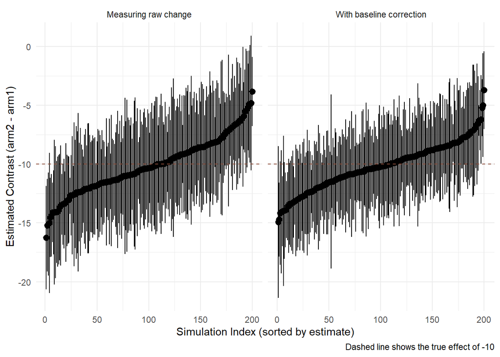

```r
    set.seed(999)
    n_sim <- 200
    res_baseline <- data.frame()

    # pb <- txtProgressBar(min = 0, max = n_sim, style = 3)

    for (i in 1:n_sim) {
      dat <- sim_baseline_study(n_g = 5, eff = 10, eff_corr = 0.3, sd = 3)

      # 1) no baseline correction
      mod_nobc <- lm(change ~ arm, data = dat)
      tmp_nobc <- emmeans(mod_nobc, ~ arm) %>%
        contrast("pairwise") %>%
        as.data.frame()
      tmp_nobc$model <- "Measuring raw change"
      tmp_nobc$rep   <- i

      # 2) with baseline correction
      mod_bc <- lm(y_after ~ arm + y_before, data = dat)
      tmp_bc <- emmeans(mod_bc, ~ arm) %>%
        contrast("pairwise") %>%
        as.data.frame()
      tmp_bc$model <- "With baseline correction"
      tmp_bc$rep   <- i

      res_baseline <- rbind(res_baseline, tmp_nobc, tmp_bc)
      # setTxtProgressBar(pb, i)
    }
    # close(pb)

    res_baseline <- res_baseline %>%
      mutate(ci_low = estimate - 1.96 * SE,
             ci_upp = estimate + 1.96 * SE)

    res_baseline <- res_baseline %>%
      group_by(model) %>%
      arrange(estimate, .by_group = TRUE) %>%
      mutate(id = row_number()) %>%
      ungroup()

      ggplot(res_baseline, aes(x = id, y = estimate, ymin = ci_low, ymax = ci_upp)) +
      geom_pointrange() +
      facet_wrap(~ model, scales = "free_x") +
      geom_hline(yintercept = -10, linetype = "dashed", color = "salmon4") +
      theme_minimal() +
      labs(
        x = "Simulation Index (sorted by estimate)",
        y = "Estimated Contrast (arm2 - arm1)",
        caption = "Dashed line shows the true effect of -10"
      )
```

Yup, baseline correction results in more consistent estimations overall. Using baseline as a covariate typically shrinks standard errors (too).

# 4. A Spline for Baseline?

You *could* assume a linear relationship between baseline and outcome. But, lets get greedy, and let the model estimate the relationship with an additional parameter through a natural spline.

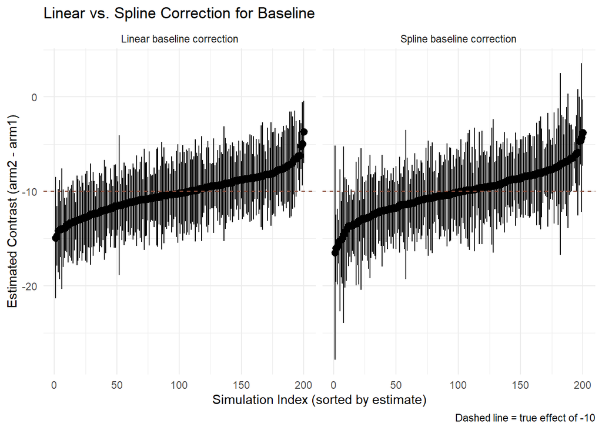

```r
    set.seed(999)
    n_sim <- 200
    res_baseline <- data.frame()

    # pb <- txtProgressBar(min = 0, max = n_sim, style = 3)

    for (i in 1:n_sim) {
      dat <- sim_baseline_study(n_g = 5, eff = 10, eff_corr = 0.3, sd = 3)

      # Linear baseline correction
      mod_bc <- lm(y_after ~ arm + y_before, data = dat)
      tmp_bc <- emmeans(mod_bc, ~ arm) %>%
        contrast("pairwise") %>%
        as.data.frame()
      tmp_bc$model <- "Linear baseline correction"
      tmp_bc$rep   <- i

      # Spline-based correction
      mod_bcsp <- lm(y_after ~ arm + ns(y_before, df = 2), data = dat)
      tmp_bcsp <- emmeans(mod_bcsp, ~ arm) %>%
        contrast("pairwise") %>%
        as.data.frame()
      tmp_bcsp$model <- "Spline baseline correction"
      tmp_bcsp$rep   <- i

      res_baseline <- rbind(res_baseline, tmp_bc, tmp_bcsp)
      # setTxtProgressBar(pb, i)
    }
    # close(pb)

    res_baseline <- res_baseline %>%
      mutate(ci_low = estimate - 1.96 * SE,
             ci_upp = estimate + 1.96 * SE)

    res_baseline <- res_baseline %>%
      group_by(model) %>%
      arrange(estimate, .by_group = TRUE) %>%
      mutate(id = row_number()) %>%
      ungroup()

      ggplot(res_baseline, aes(x = id, y = estimate, ymin = ci_low, ymax = ci_upp)) +
      geom_pointrange() +
      facet_wrap(~ model, scales = "free_x") +
      geom_hline(yintercept = -10, linetype = "dashed", color = "salmon4") +
      theme_minimal() +
      labs(
        x = "Simulation Index (sorted by estimate)",
        y = "Estimated Contrast (arm2 - arm1)",
        title = "Linear vs. Spline Correction for Baseline",
        caption = "Dashed line = true effect of -10"
      )
```

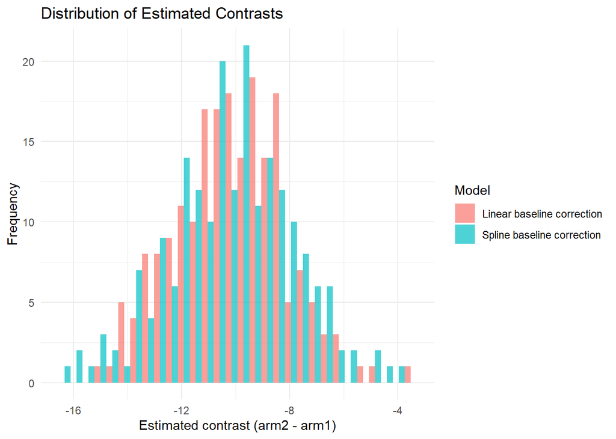

```r
      res_baseline %>%
      ggplot(aes(x = estimate, fill = model)) +
      geom_histogram(bins = 30, position = "dodge", alpha = 0.7) +
      theme_minimal() +
      labs(
        x = "Estimated contrast (arm2 - arm1)",
        y = "Frequency",
        fill = "Model",
        title = "Distribution of Estimated Contrasts"
      )
```

Yeah, we didn’t do anything groundbreaking, this seems somewhat less consistent. But it’s a nice demonstration of how flexible modeling can be and to illustrate how to check ideas if you happen to have them.

# Wrap-Up

Congrats! You hopefully enjoyed this small a series of simulation-based demos about:

- **Ignoring major covariates**
- **Using covariates**: Actually seeing that the treatment effect estimates remain consistent even if the covariates are extreme.
- **Baseline corrections**: It seems that investigating change really isnt the best approach.
- **Splines**: Because if you can’t add a bit of curve to your model, where’s the fun?

In actual clinical trial practice, you’d *prespecify* whether or not to include these covariates or baseline adjustments. That’s to avoid data snooping and ensure your type I error rate stays honest.

*(Now go forth and model responsibly!)*